# Multivariate Plots Section

Technically some of the bivariate plots could be considred multivariate since rates are derivative of more than once variable. Below I try to understand whether relationships signifcantly as a function of year or school type. I also include some other visualizatons to help foster an understanding of the data.

## Rates vs. total exemptions, by year

How are exemptions rates changing as a function of total exemptions, per year. For this and other sections in multivariate plots, I would like to know if there are any major differences from year to year that will help inform conclusions and plots.

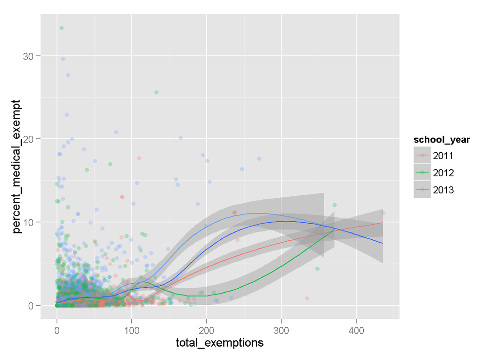

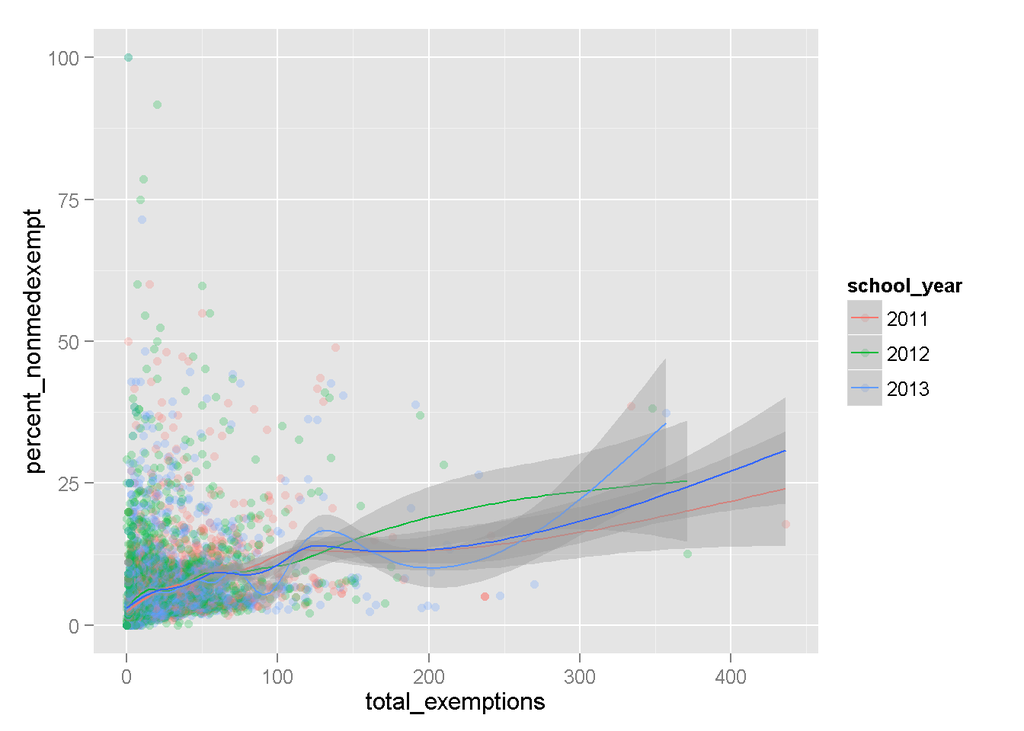

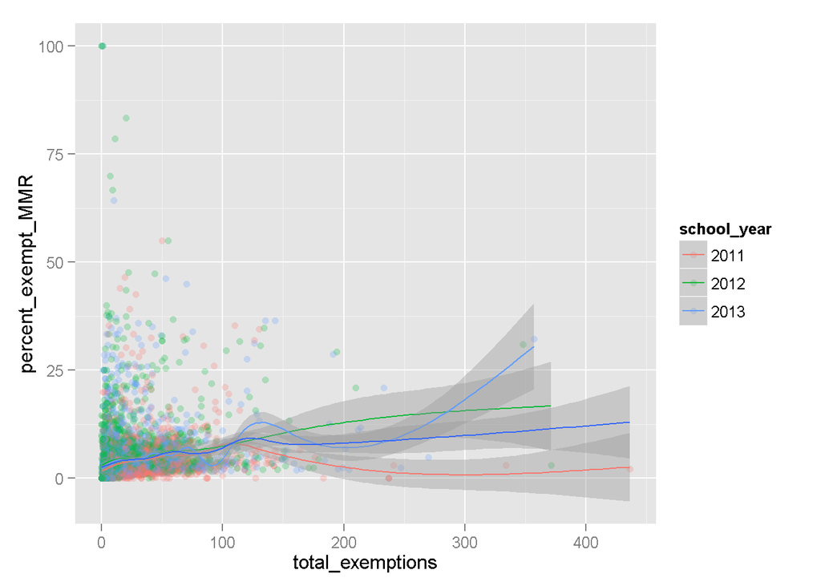

- Observing year to year variation, particularly beyond 100 total exemptions

## Specific exemptions vs. total exemptions by school year and by school type

Is the relationship between specific exemptions and overall exemptions varying markedly year to year or by school type?

By school year:

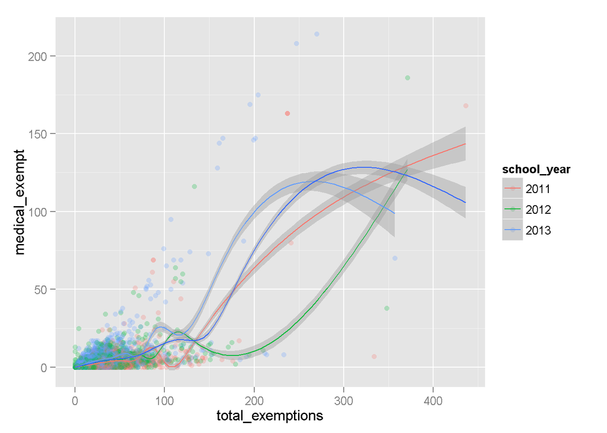

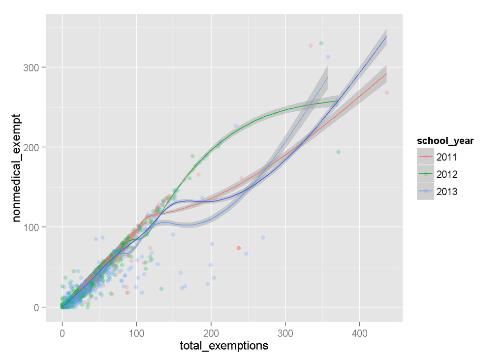

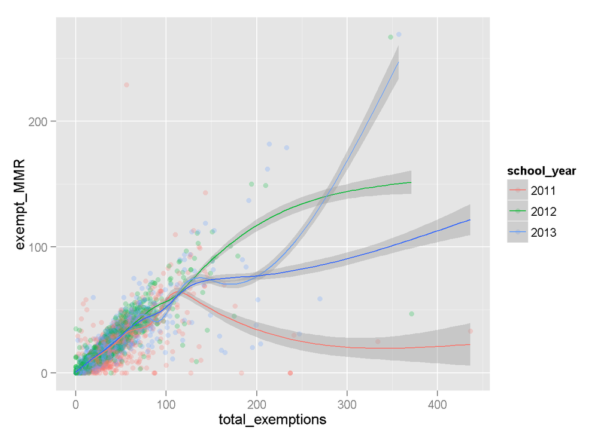

By school type:

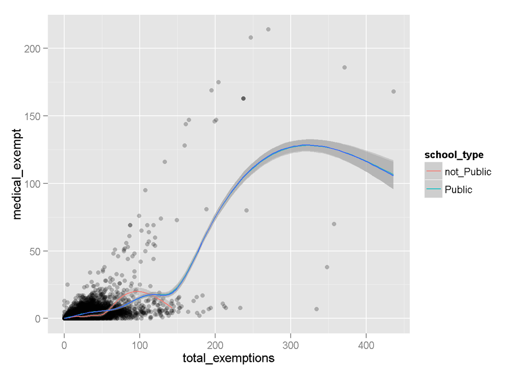

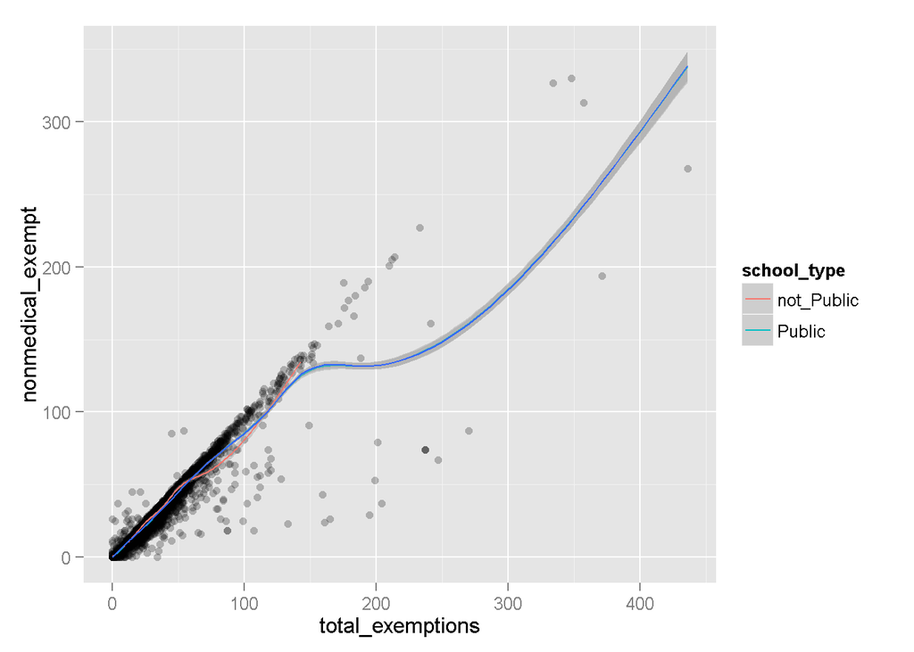

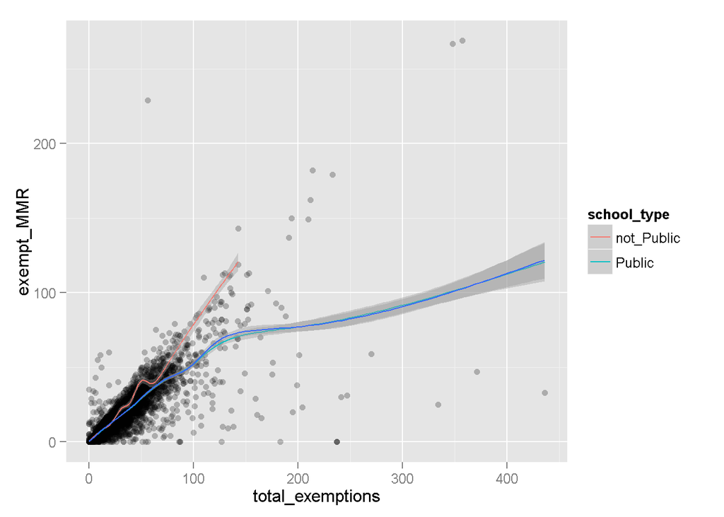

- Observing year to year variation, particularly beyond 100 total exemptions
- observing little varition in non-medical exempt by type
- observing a divergence in rate between public and private schools for MMR exemptions

## Rate vs. rate by year

How are specific exemption rates and total rate varying as by school year?

First a general look:

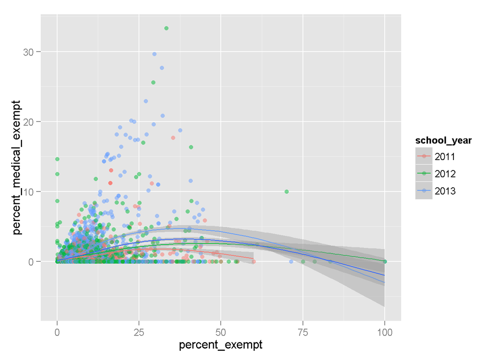

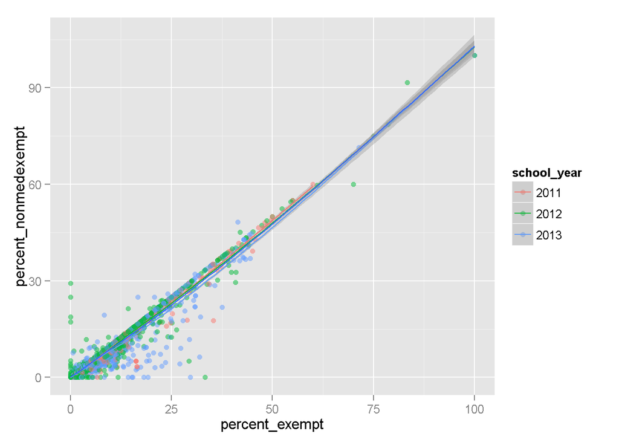

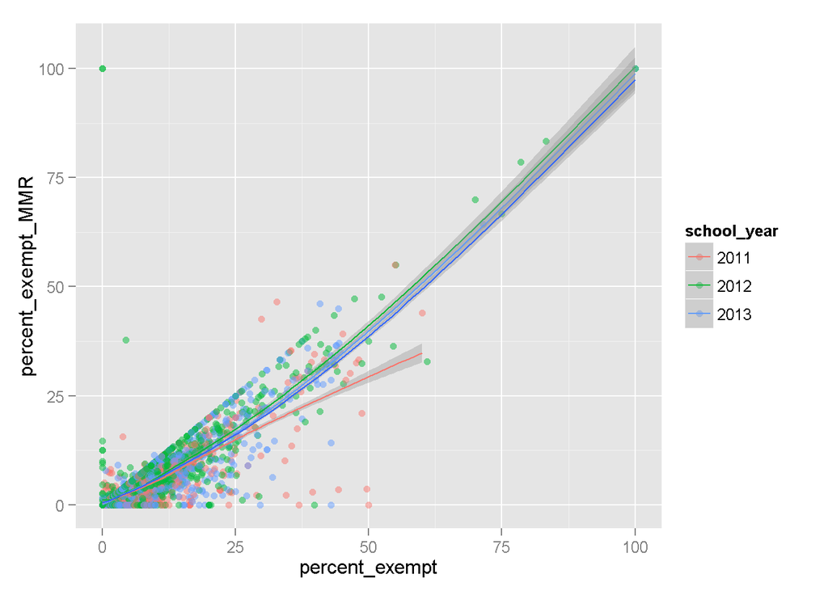

Now a closer look faceted by year:

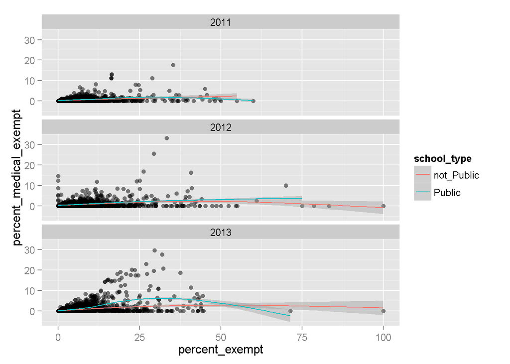

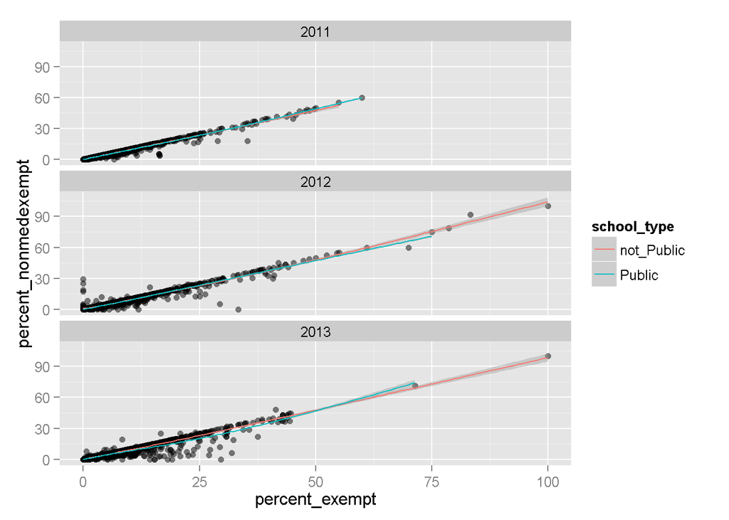

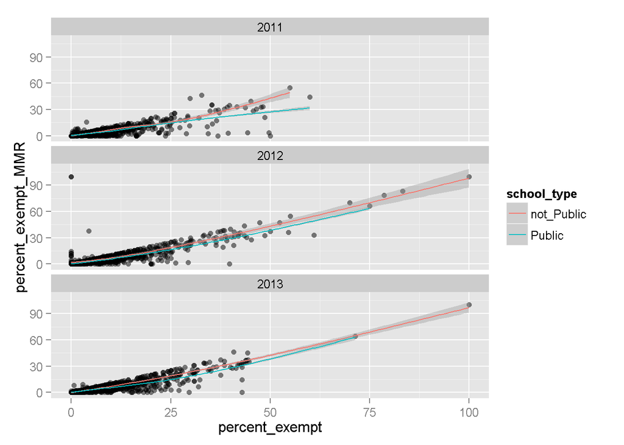

- observing minimal variation for percent non-medical exempt by year and school type
- observing some variation for 2011 percent exempt MMR at ~ > 25% total exemptions by year
- observing some variation for 2011 percent exempt MMR at ~ > 40% total exemptions by school type

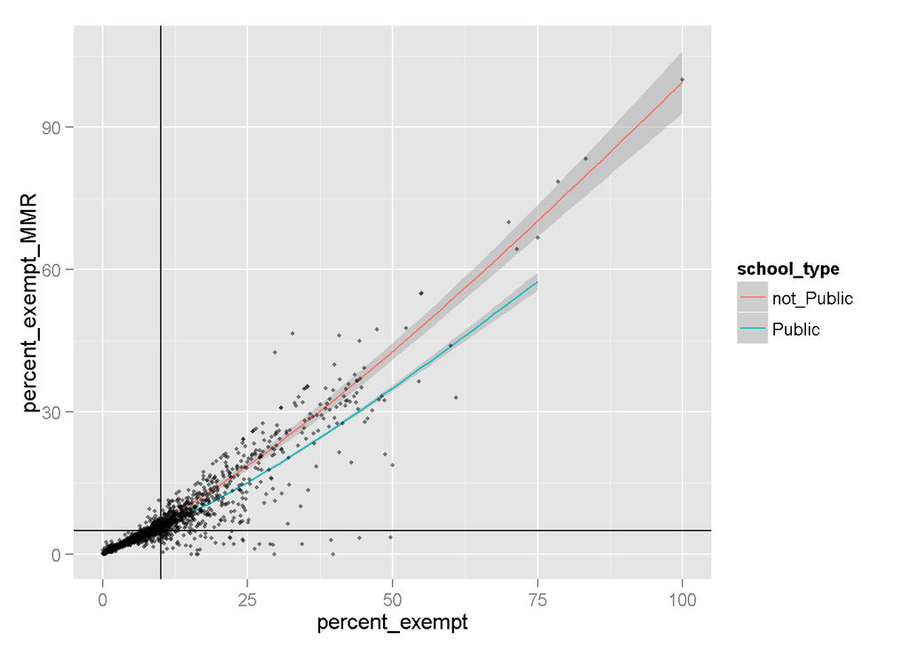

### Repeat on subset of vaccreported with enrollment of >=100 and <= 2500.

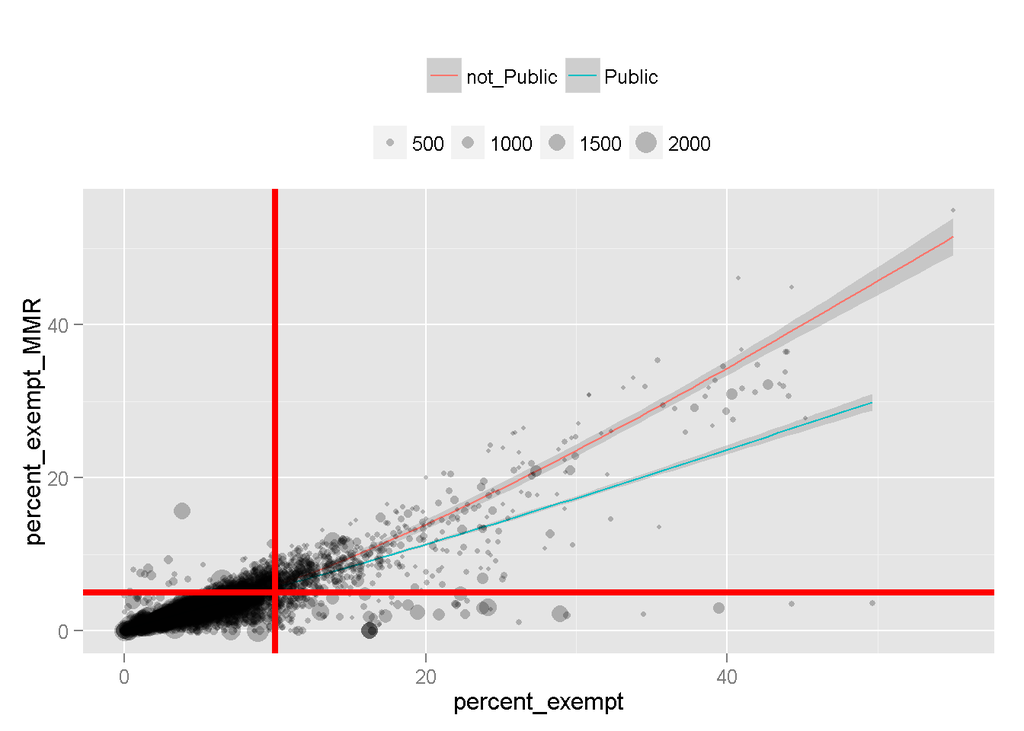

- The majority of the data falls below both thresholds
- The school types start to diverge near the intersection of 5% MMR exemption rate and 10% total exemption rate
- There is a subset of data that is above the MMR rate threshold but below the total exemption rate threshold
- There is a subset of data that is below the MMR rate threshold but above the total exemption rate threshold

## Group by County and School Type

```
## Classes 'tbl_df', 'tbl' and 'data.frame':    39 obs. of  19 variables:
##  $ school_county                : chr  "KING" "PIERCE" "SNOHOMISH" "CLARK" ...
##  $ mean_percent_medical_exempt  : num  1.99 0.72 1.13 0.59 0.87 0.27 0.96 1.15 0.5 1.2 ...
##  $ median_percent_medical_exempt: num  0.82 0.52 0.68 0.5 0.59 0.16 0.73 0.55 0.21 0.83 ...
##  $ max_percent_medical_exempt   : num  29.63 7.46 12.26 2.3 14.29 ...
##  $ min_percent_medical_exempt   : num  0 0 0 0 0 0 0 0 0 0 ...
##  $ mean_percent_exempt_MMR      : num  3.51 2.96 4.42 5.36 5.5 1.37 5.26 4.67 3.19 6.33 ...
##  $ median_percent_exempt_MMR    : num  2.48 2.23 3.3 4.57 3.57 0.76 3.91 3.55 2.26 4.38 ...
##  $ max_percent_exempt_MMR       : num  36.5 33.1 32.2 36.5 44.9 ...
##  $ min_percent_exempt_MMR       : num  0 0 0 0 0 0 0 0.62 0 0 ...
##  $ mean_percent_exempt          : num  6.77 4.42 6.96 7.27 8.15 2.13 7.55 7.44 4.1 9.69 ...
##  $ median_percent_exempt        : num  5.03 3.66 5.42 6.5 6.03 1.38 5.97 5.95 3.21 7.27 ...
##  $ max_percent_exempt           : num  43.9 33.8 42.7 44 44.3 ...
##  $ min_percent_exempt           : num  0 0 0 0 0 0 0 1.25 0 0 ...
##  $ mean_percent_nonmedexempt    : num  4.99 3.88 5.97 6.84 7.3 1.91 6.7 6.44 3.62 8.58 ...
##  $ median_percent_nonmedexempt  : num  3.6 2.97 4.66 6.14 5.35 1.14 4.88 5.13 2.95 6.55 ...
##  $ max_percent_nonmedexempt     : num  42.9 33.8 37.4 42.7 44.3 ...
##  $ min_percent_nonmedexempt     : num  0 0 0 0 0 0 0 0.42 0 0 ...
##  $ schools                      : int  581 253 205 129 165 90 86 78 57 72 ...
##  $ students                     : num  289034 132412 108104 78252 76901 ...
```

```
## Classes 'grouped_df', 'tbl_df', 'tbl' and 'data.frame':  69 obs. of  20 variables:
##  $ school_county                : chr  "ADAMS" "ASOTIN" "ASOTIN" "BENTON" ...
##  $ school_type                  : Factor w/ 2 levels "not_Public","Public": 2 2 1 2 1 2 1 2 1 2 ...
##  $ mean_percent_medical_exempt  : num  0.22 2.29 0 0.36 1.56 0.33 0 0.64 5.34 0.64 ...
##  $ median_percent_medical_exempt: num  0.19 2.29 0 0.22 0 0.22 0 0.46 0.87 0.55 ...
##  $ max_percent_medical_exempt   : num  0.74 2.47 0 2.78 7.27 ...
##  $ min_percent_medical_exempt   : num  0 2.11 0 0 0 0 0 0 0 0 ...
##  $ mean_percent_exempt_MMR      : num  3.71 3.7 2.97 2.9 5.26 ...
##  $ median_percent_exempt_MMR    : num  1.31 3.7 2.97 2.23 4 ...
##  $ max_percent_exempt_MMR       : num  30.77 5.3 2.97 14.7 12.5 ...
##  $ min_percent_exempt_MMR       : num  0.22 2.11 2.97 0 0 0 1.4 0 1.55 0 ...
##  $ mean_percent_exempt          : num  5.57 5.59 4.95 3.77 6.45 ...
##  $ median_percent_exempt        : num  2.03 5.59 4.95 3.19 7.94 ...
##  $ max_percent_exempt           : num  38.46 6.36 4.95 21.09 12.5 ...
##  $ min_percent_exempt           : num  0.87 4.82 4.95 0 0 0.67 1.4 0 4.65 0.15 ...
##  $ mean_percent_nonmedexempt    : num  5.36 3.3 4.95 3.44 4.89 ...
##  $ median_percent_nonmedexempt  : num  1.79 3.3 4.95 2.88 4.8 ...
##  $ max_percent_nonmedexempt     : num  38.46 3.89 4.95 21.09 12.5 ...
##  $ min_percent_nonmedexempt     : num  0.43 2.71 4.95 0 0 0.45 1.4 0 4.65 0 ...
##  $ schools                      : int  13 2 1 50 7 29 2 21 4 113 ...
##  $ students                     : num  6040 615 101 33026 1133 ...
##  - attr(*, "vars")=List of 1
##   ..$ : symbol school_county
##  - attr(*, "indices")=List of 39
##   ..$ : int 0
##   ..$ : int  1 2
##   ..$ : int  3 4
##   ..$ : int  5 6
##   ..$ : int  7 8
##   ..$ : int  9 10
##   ..$ : int 11
##   ..$ : int  12 13
##   ..$ : int 14
##   ..$ : int  15 16
##   ..$ : int  17 18
##   ..$ : int 19
##   ..$ : int  20 21
##   ..$ : int  22 23
##   ..$ : int  24 25
##   ..$ : int  26 27
```

[output cut: 14 more lines]

[output not shown]

## Bar Plots

Bar plots using the county_group and county_group_type data frames.

### Mean Total and MMR exemption rates by school type

County level data for mean MMR and total exemption rates. The y axis is ordered by number of stuents enrolled for each county. I used position = dodge for side by side comparison and position = fill to show the proportion contribution of each school type to the mean rate.

Students per county

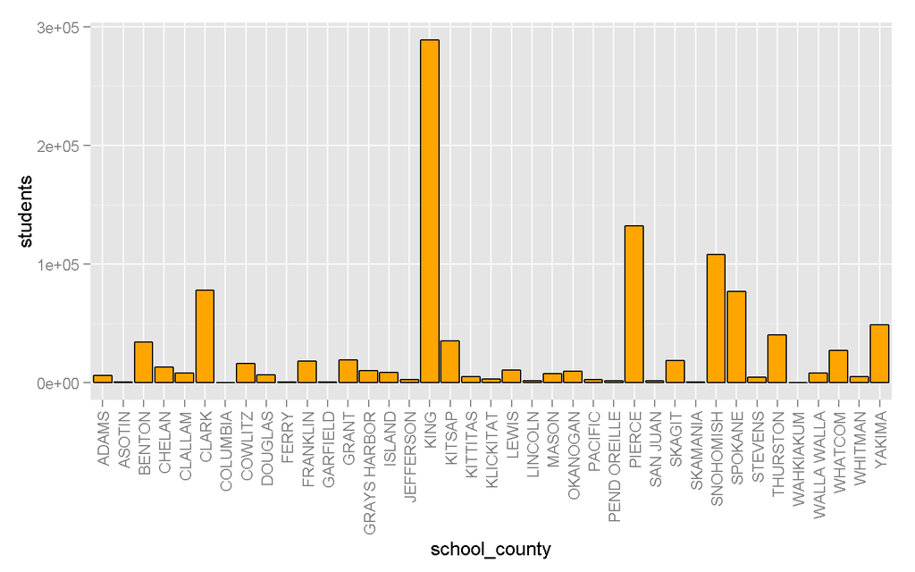

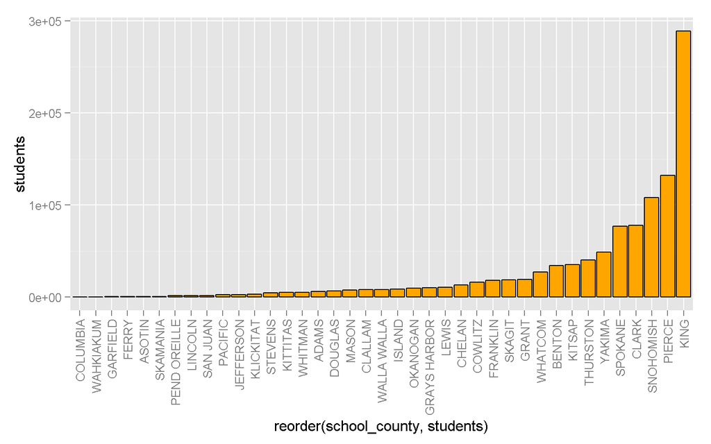

There is a large range of students per county. I’m reordering subsequent plots by descending number of students.

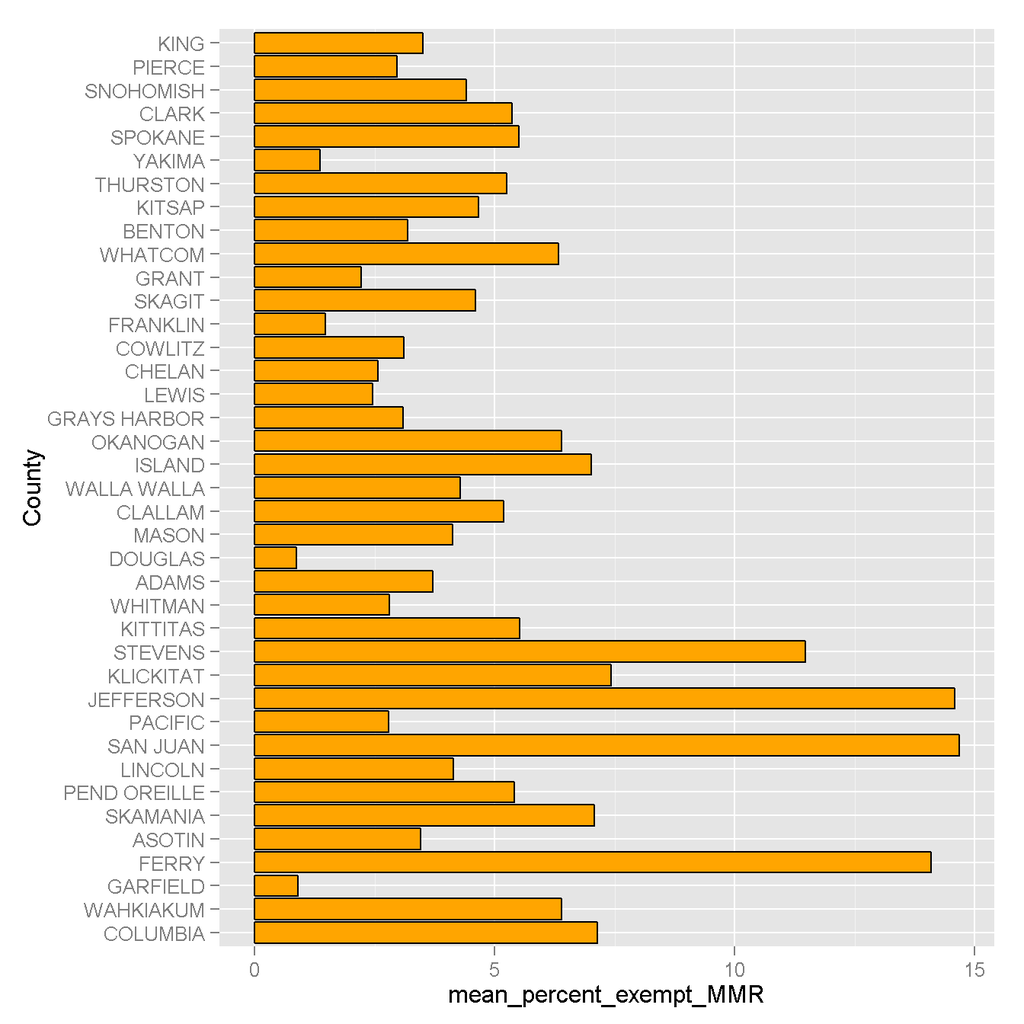

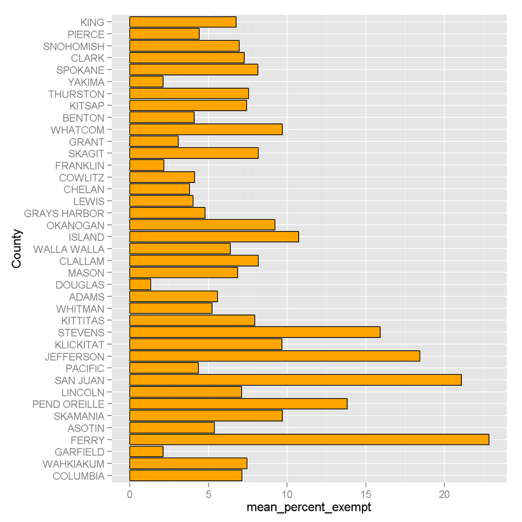

It is very clear from these bar plots that there are many counties with mean total and MMR exemption rates exceeding the 10% and 5% thresholds, respectively. It is also clear that this does not cut on student population. There are several smaller counties with very high rates of exemption. However, the total exemptions are much smaller, than for larger counties. For example Ferry has only 678 students for the 2013-2014 school year, spread accross several schools.

#### By school type

County level data for mean MMR and total exemption rates, by school type. The y axis is ordered by number of students enrolled for each county.

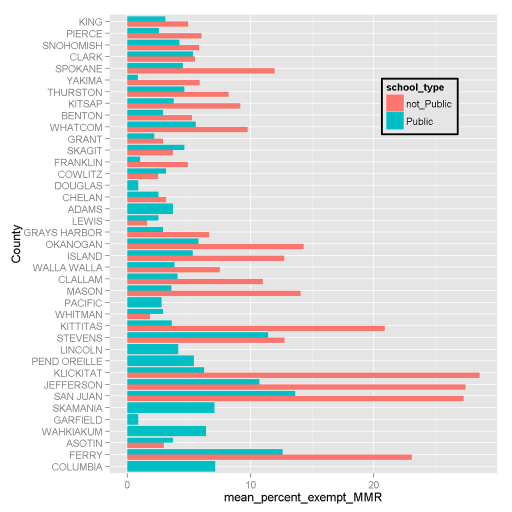

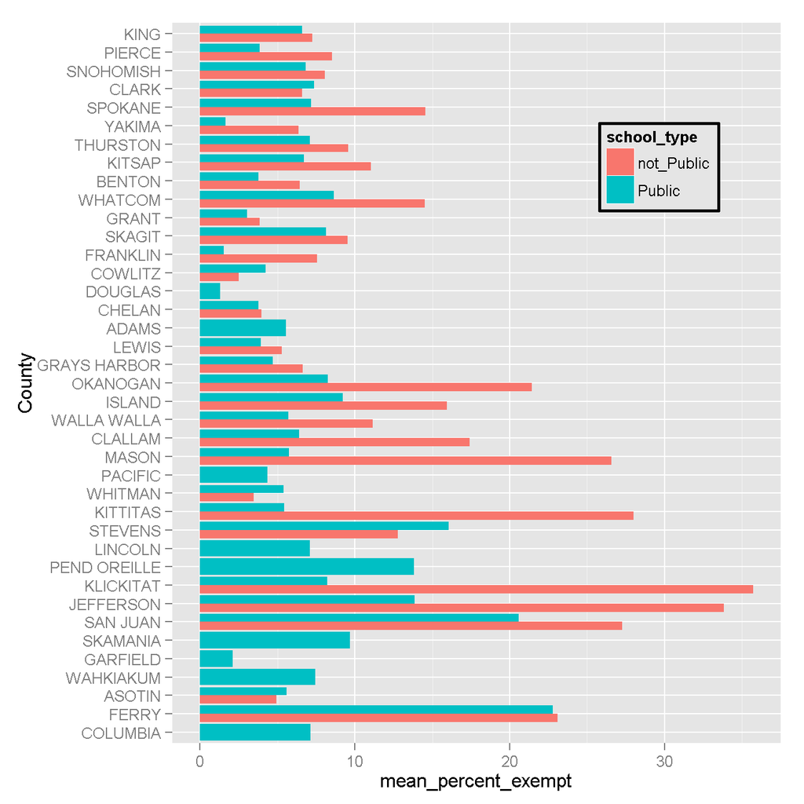

For both MMR and total exemption rates, private schools are comparable to or exceed public school exemption rates for many counties.

#### By exemption type

Melting the county_group dataframe for additional bar plot visualizatons.  
Melt is achieved by using gather() [tidyr package], where mean_percent_medical_exempt and mean_percent_nonmedexempt are gathered into exemption type, with each individual mean captured in mean_percent_exemption_type.

```
## Observations: 39
## Variables:
## $ school_county                 (chr) "KING", "PIERCE", "SNOHOMISH", "...
## $ mean_percent_medical_exempt   (dbl) 1.99, 0.72, 1.13, 0.59, 0.87, 0....
## $ median_percent_medical_exempt (dbl) 0.82, 0.52, 0.68, 0.50, 0.59, 0....
## $ max_percent_medical_exempt    (dbl) 29.63, 7.46, 12.26, 2.30, 14.29,...
## $ min_percent_medical_exempt    (dbl) 0, 0, 0, 0, 0, 0, 0, 0, 0, 0, 0,...
## $ mean_percent_exempt_MMR       (dbl) 3.51, 2.96, 4.42, 5.36, 5.50, 1....
## $ median_percent_exempt_MMR     (dbl) 2.48, 2.23, 3.30, 4.57, 3.57, 0....
## $ max_percent_exempt_MMR        (dbl) 36.50, 33.10, 32.18, 36.48, 44.9...
## $ min_percent_exempt_MMR        (dbl) 0.00, 0.00, 0.00, 0.00, 0.00, 0....
## $ mean_percent_exempt           (dbl) 6.77, 4.42, 6.96, 7.27, 8.15, 2....
## $ median_percent_exempt         (dbl) 5.03, 3.66, 5.42, 6.50, 6.03, 1....
## $ max_percent_exempt            (dbl) 43.87, 33.79, 42.70, 43.97, 44.3...
## $ min_percent_exempt            (dbl) 0.00, 0.00, 0.00, 0.00, 0.00, 0....
## $ mean_percent_nonmedexempt     (dbl) 4.99, 3.88, 5.97, 6.84, 7.30, 1....
## $ median_percent_nonmedexempt   (dbl) 3.60, 2.97, 4.66, 6.14, 5.35, 1....
## $ max_percent_nonmedexempt      (dbl) 42.86, 33.79, 37.44, 42.67, 44.3...
## $ min_percent_nonmedexempt      (dbl) 0.00, 0.00, 0.00, 0.00, 0.00, 0....
## $ schools                       (int) 581, 253, 205, 129, 165, 90, 86,...
## $ students                      (dbl) 289034, 132412, 108104, 78252, 7...
```

```
## Observations: 78
## Variables:
## $ school_county                 (chr) "KING", "PIERCE", "SNOHOMISH", "...
## $ median_percent_medical_exempt (dbl) 0.82, 0.52, 0.68, 0.50, 0.59, 0....
## $ max_percent_medical_exempt    (dbl) 29.63, 7.46, 12.26, 2.30, 14.29,...
## $ min_percent_medical_exempt    (dbl) 0, 0, 0, 0, 0, 0, 0, 0, 0, 0, 0,...
## $ mean_percent_exempt_MMR       (dbl) 3.51, 2.96, 4.42, 5.36, 5.50, 1....
## $ median_percent_exempt_MMR     (dbl) 2.48, 2.23, 3.30, 4.57, 3.57, 0....
## $ max_percent_exempt_MMR        (dbl) 36.50, 33.10, 32.18, 36.48, 44.9...
## $ min_percent_exempt_MMR        (dbl) 0.00, 0.00, 0.00, 0.00, 0.00, 0....
## $ mean_percent_exempt           (dbl) 6.77, 4.42, 6.96, 7.27, 8.15, 2....
## $ median_percent_exempt         (dbl) 5.03, 3.66, 5.42, 6.50, 6.03, 1....
## $ max_percent_exempt            (dbl) 43.87, 33.79, 42.70, 43.97, 44.3...
## $ min_percent_exempt            (dbl) 0.00, 0.00, 0.00, 0.00, 0.00, 0....
## $ median_percent_nonmedexempt   (dbl) 3.60, 2.97, 4.66, 6.14, 5.35, 1....
## $ max_percent_nonmedexempt      (dbl) 42.86, 33.79, 37.44, 42.67, 44.3...
## $ min_percent_nonmedexempt      (dbl) 0.00, 0.00, 0.00, 0.00, 0.00, 0....
## $ schools                       (int) 581, 253, 205, 129, 165, 90, 86,...
## $ students                      (dbl) 289034, 132412, 108104, 78252, 7...
## $ exemption_type                (fctr) mean_percent_medical_exempt, me...
## $ mean_percent_exemption_type   (dbl) 1.99, 0.72, 1.13, 0.59, 0.87, 0....
```

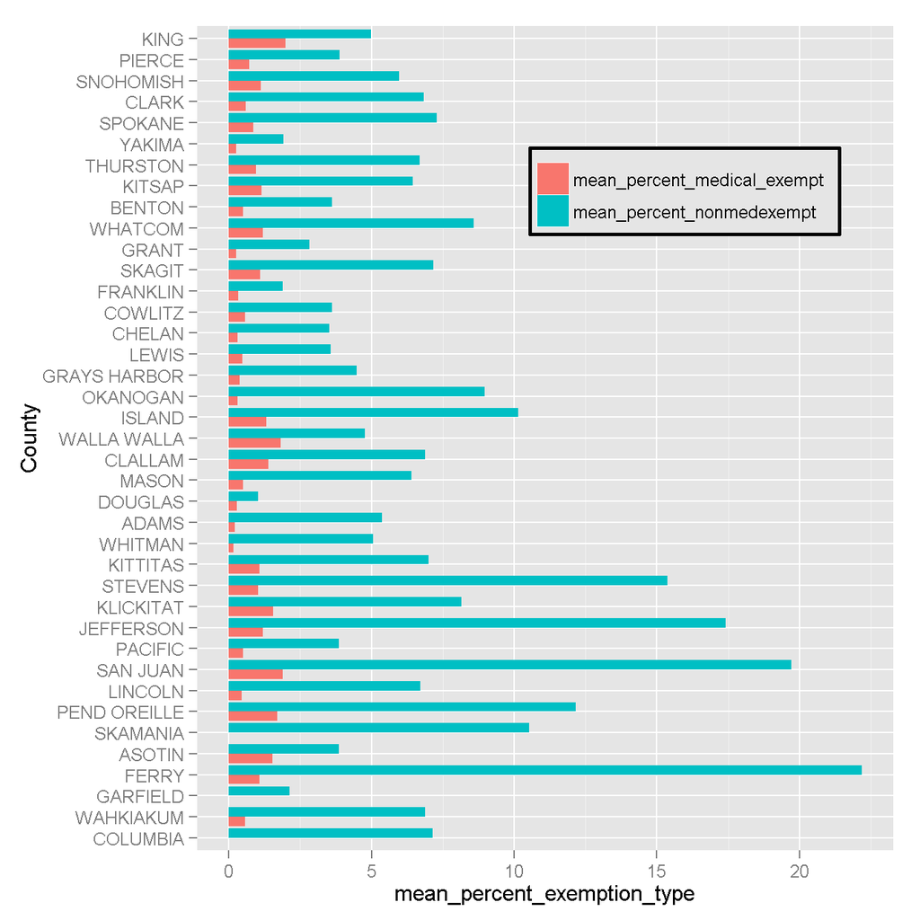

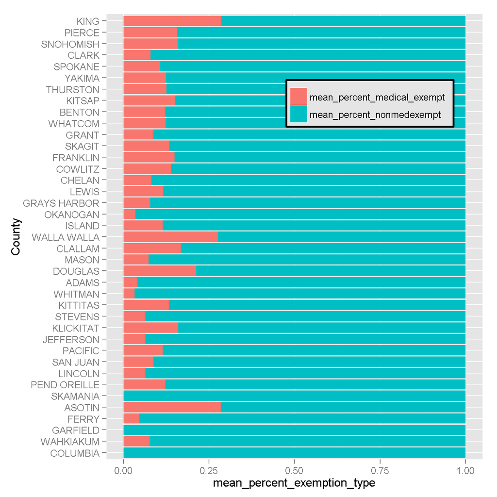

Non-medical exemptions far exceed medical exemptions for all counties, contributing 70-100% of the total exemption rate, on a proportion basis.

Add a quartile field into melt_county_group, as a factor.

```
##  [1] 2 2 2 3 3 1 3 3 1 4 1 3 1 1 1 1 2 4 4 2 3 2 1 2 2 3 4 4 4 1 4 2 4 4 2
## [36] 4 1 3 3 2 2 2 3 3 1 3 3 1 4 1 3 1 1 1 1 2 4 4 2 3 2 1 2 2 3 4 4 4 1 4
## [71] 2 4 4 2 4 1 3 3
## Levels: 1 2 3 4
```

```
## Observations: 78
## Variables:
## $ school_county                 (chr) "KING", "PIERCE", "SNOHOMISH", "...
## $ median_percent_medical_exempt (dbl) 0.82, 0.52, 0.68, 0.50, 0.59, 0....
## $ max_percent_medical_exempt    (dbl) 29.63, 7.46, 12.26, 2.30, 14.29,...
## $ min_percent_medical_exempt    (dbl) 0, 0, 0, 0, 0, 0, 0, 0, 0, 0, 0,...
## $ mean_percent_exempt_MMR       (dbl) 3.51, 2.96, 4.42, 5.36, 5.50, 1....
## $ median_percent_exempt_MMR     (dbl) 2.48, 2.23, 3.30, 4.57, 3.57, 0....
## $ max_percent_exempt_MMR        (dbl) 36.50, 33.10, 32.18, 36.48, 44.9...
## $ min_percent_exempt_MMR        (dbl) 0.00, 0.00, 0.00, 0.00, 0.00, 0....
## $ mean_percent_exempt           (dbl) 6.77, 4.42, 6.96, 7.27, 8.15, 2....
## $ median_percent_exempt         (dbl) 5.03, 3.66, 5.42, 6.50, 6.03, 1....
## $ max_percent_exempt            (dbl) 43.87, 33.79, 42.70, 43.97, 44.3...
## $ min_percent_exempt            (dbl) 0.00, 0.00, 0.00, 0.00, 0.00, 0....
## $ median_percent_nonmedexempt   (dbl) 3.60, 2.97, 4.66, 6.14, 5.35, 1....
## $ max_percent_nonmedexempt      (dbl) 42.86, 33.79, 37.44, 42.67, 44.3...
## $ min_percent_nonmedexempt      (dbl) 0.00, 0.00, 0.00, 0.00, 0.00, 0....
## $ schools                       (int) 581, 253, 205, 129, 165, 90, 86,...
## $ students                      (dbl) 289034, 132412, 108104, 78252, 7...
## $ exemption_type                (fctr) mean_percent_medical_exempt, me...
## $ mean_percent_exemption_type   (dbl) 1.99, 0.72, 1.13, 0.59, 0.87, 0....
## $ mean_percent_exempt_quartile  (int) 2, 2, 2, 3, 3, 1, 3, 3, 1, 4, 1,...
```

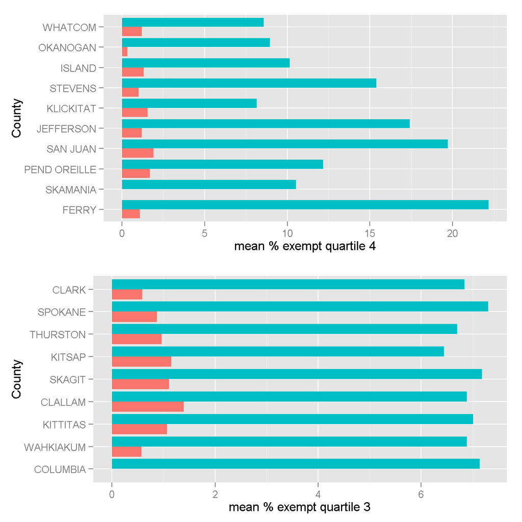

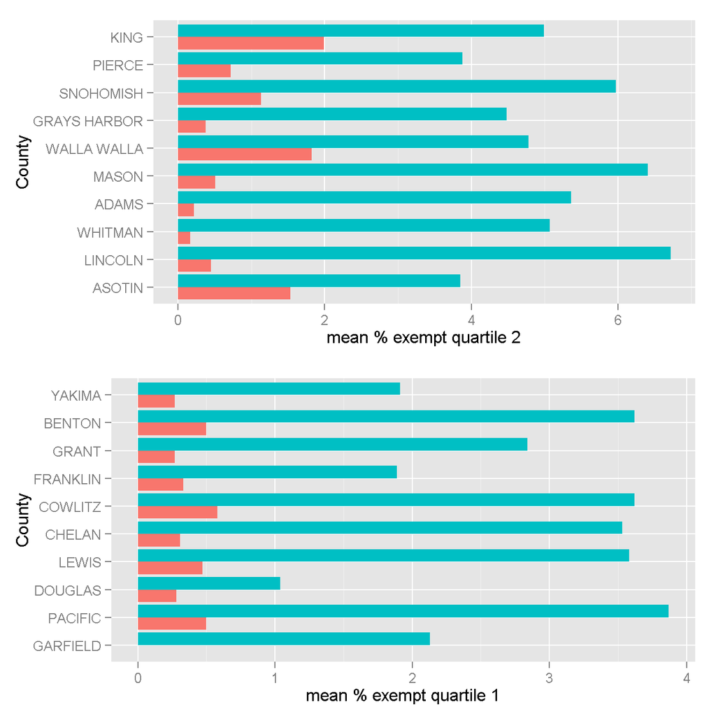

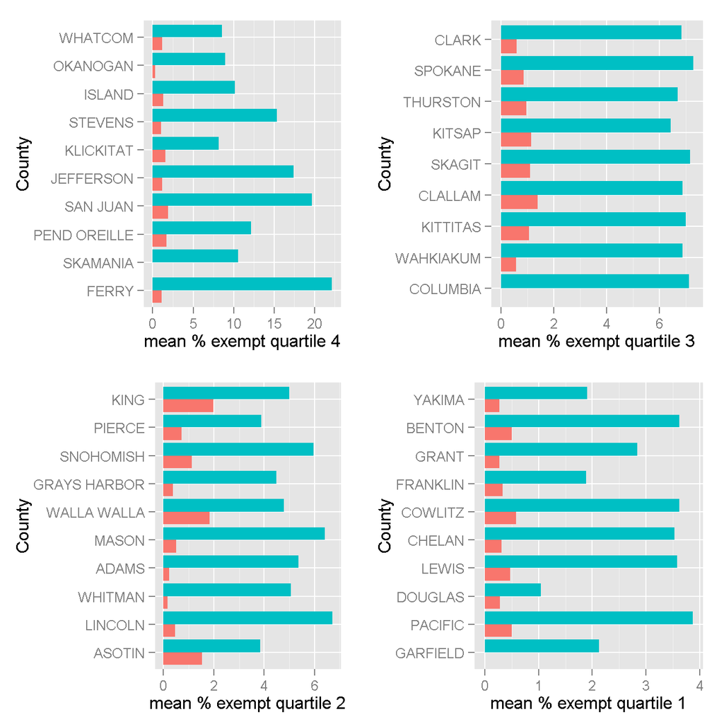

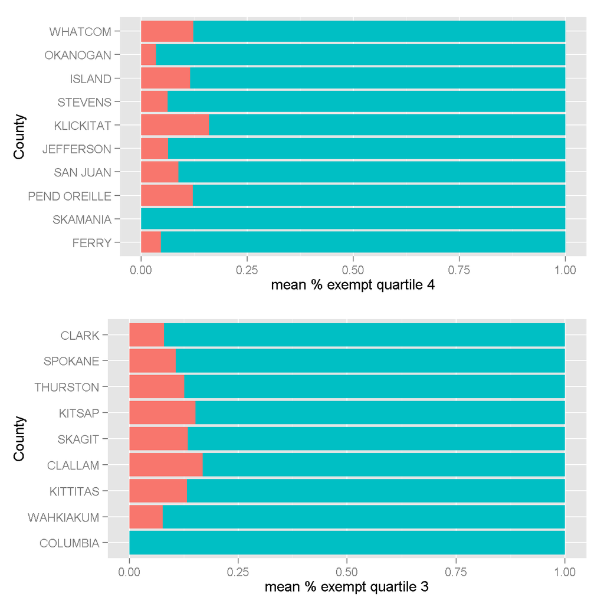

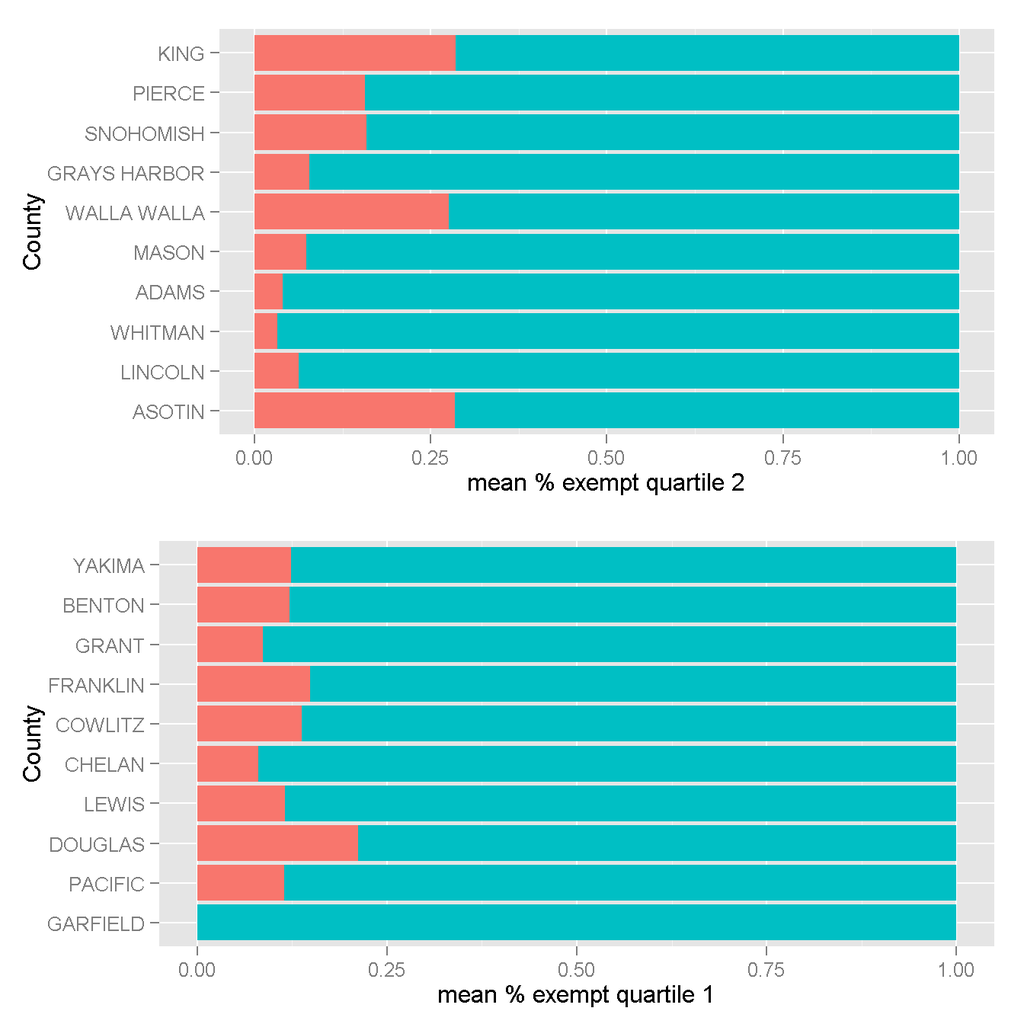

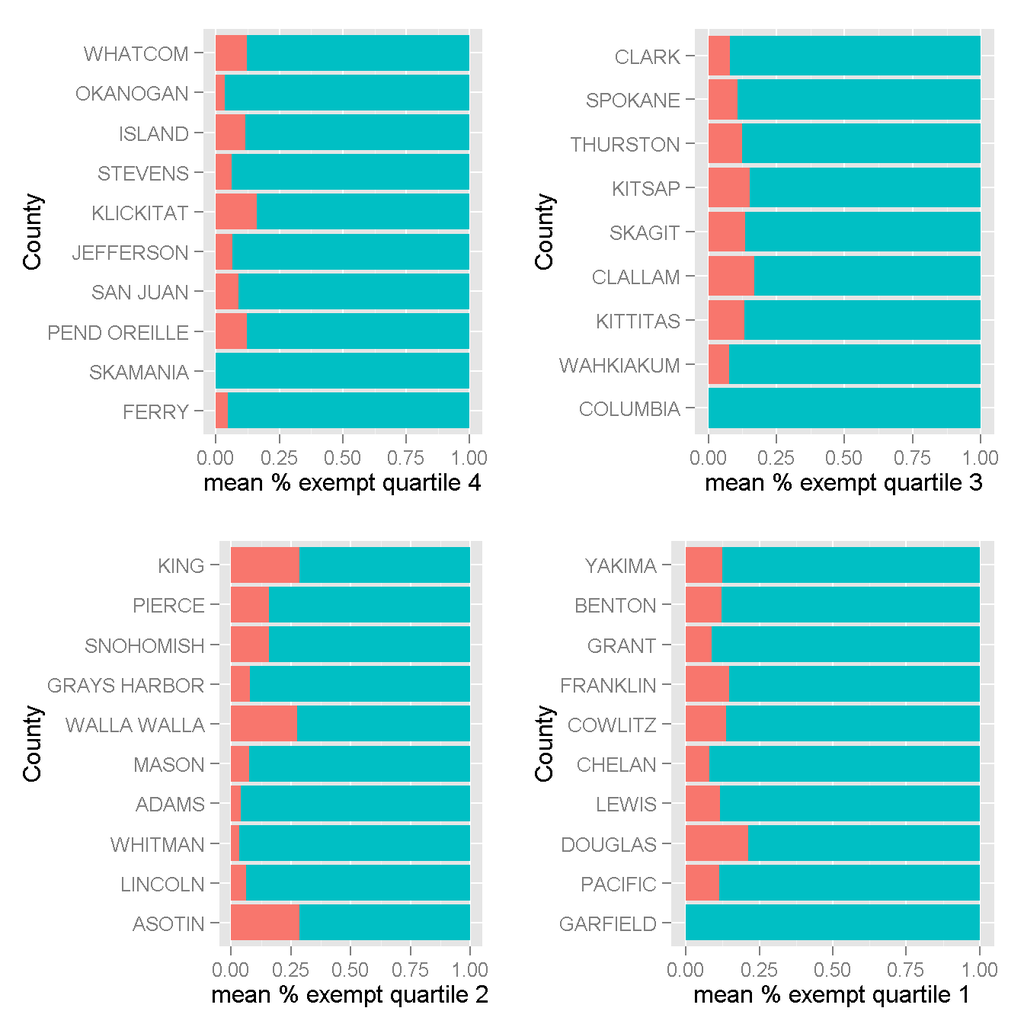

Below I use position = stack and add labels. My intent was to show the total exemption rate, the contribution from each type of exemption, and the number of students in the county. I then shade at 8% total exemption (corresponding to a roughly predicted 5% MMR exemption rate) to show danger zone. HOwever, it looks like stack is just “stacking”, rather than adjusting proportions. The plots also suffer from other short-comings. I’m leaving them here just to illustrate the code and hoping that coaches will have some suggestions for improvements.

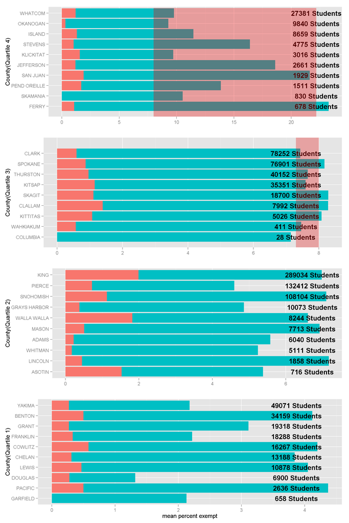

# Multivariate Analysis

### Talk about some of the relationships you observed in this part of the investigation. Were there features that strengthened each other in terms of looking at your feature(s) of interest?

I didn’t observe any relationships that stand out fromt the bivariate plots section.

### Were there any interesting or surprising interactions between features?

There were not suprising interactions. However, it was intersting to see some of the highest mean exemption rates were in smaller counties. Previously I had noticed that there was a large variance in exemption rates on the smaller end of the enrollement spectrum, which is consitent with what I’m seeing at the county level.